# 発表資料例

後藤 晶

# 分析1：独立性の検定：χ二乗検定

## 仮説

- 対立仮説：居住地域と子供の有無は独立ではない（関連がある）
- 帰無仮説：居住地域と子供の有無は独立である（関連があるとは言えない）

## 結果

- テーブルを作成する

```r
tablee<-table(exdataset$CHI, exdataset$ARE)
tablee
```

```
##
##           Kanto Hokkaido Tohoku Chubu Kinki Chugoku Shikoku Kyushu
##   NoChild   192       14     35    68    79      31      10     39
##   Child     184       21     29    80    86      34       8     53
```

- χ二乗検定を実施する

```r
chitest.tablee<-chisq.test(tablee)
chitest.tablee
```

```
##
##  Pearson's Chi-squared test
##
## data:  tablee
## X-squared = 5.1408, df = 7, p-value = 0.6428
```

## 考察

- $\chi^2(7)=5.14，p=.64$であり，有意差は認められない．
- したがって，ここでは帰無仮説を採択する．
- 居住地域と子供の有無は独立であると考えられる．

# 分析2：2群の平均値の差：ダミー回帰分析ort検定

## 仮説

- 対立仮説：未婚者と既婚者の主観的幸福度に差がある．
- 帰無仮説：未婚者と既婚者の主観的幸福度に差があるとはいえない．

## グラフ

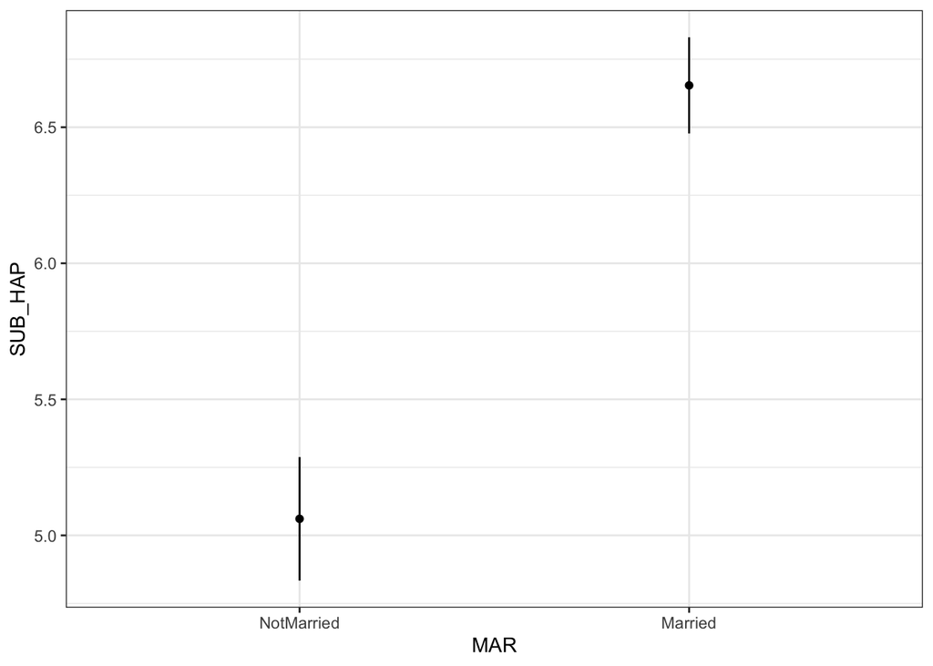

```r
# You need the following package(s):
library("ggplot2")

# The code below will generate the graph:
graph <- ggplot(exdataset, aes(x = MAR, y = SUB_HAP)) +
  geom_point(stat = 'summary', fun.y = 'mean') +
  geom_errorbar(stat = 'summary', fun.data = 'mean_se',
                width=0, fun.args = list(mult = 1.96)) +
  theme_bw()
graph
```

## 結果

```r
#"hapsat_model"というオブジェクトに，分析モデルを代入する．
marhap_model<-lm(SUB_HAP ~ MAR, data = exdataset)
    #分析結果の要約を出力する
summary(marhap_model)
```

```
##
## Call:
## lm(formula = SUB_HAP ~ MAR, data = exdataset)
##
## Residuals:
##     Min      1Q  Median      3Q     Max
## -6.6538 -1.6538  0.3462  1.3462  4.9391
##
## Coefficients:
##             Estimate Std. Error t value Pr(>|t|)
## (Intercept)   5.0609     0.1115   45.41   <2e-16 ***
## MARMarried    1.5929     0.1450   10.99   <2e-16 ***
## ---
## Signif. codes:  0 '***' 0.001 '**' 0.01 '*' 0.05 '.' 0.1 ' ' 1
##
## Residual standard error: 2.212 on 961 degrees of freedom
## Multiple R-squared:  0.1116, Adjusted R-squared:  0.1106
## F-statistic: 120.7 on 1 and 961 DF,  p-value: < 2.2e-16
```

## 結果（上の形式でも下の形式でも構わない）

```r
t.test(SUB_HAP ~ MAR, data = exdataset)
```

```
##
##  Welch Two Sample t-test
##
## data:  SUB_HAP by MAR
## t = -10.854, df = 808.29, p-value < 2.2e-16
## alternative hypothesis: true difference in means is not equal to 0
## 95 percent confidence interval:
##  -1.88094 -1.30479
## sample estimates:
## mean in group NotMarried    mean in group Married
##                 5.060914                 6.653779
```

## 考察

- 結婚ダミーの係数が1.5929，t=10.99，p<.001であり，有意な影響を与えていると考えられる．
  - 上の形式の場合
- $t(808.29)=-10.854, p<.001$であり，有意差が認められた．
  - 下の形式の場合
- したがって，対立仮説を採択する．
- $(主観的幸福度)=1.5929(結婚ダミー)+5.0609+\epsilon_i$として表すことができる．
- 未婚者に比べて，既婚者の方がおおよそ1.6程度，主観的幸福度が高い．

# 分析3：相関関係の分析：回帰分析

## 仮説

- 対立仮説：主観的幸福度と生活満足度の間に相関関係がある．
- 帰無仮説：主観的幸福度と生活満足度の間に相関関係があるとは言えない．

## グラフ

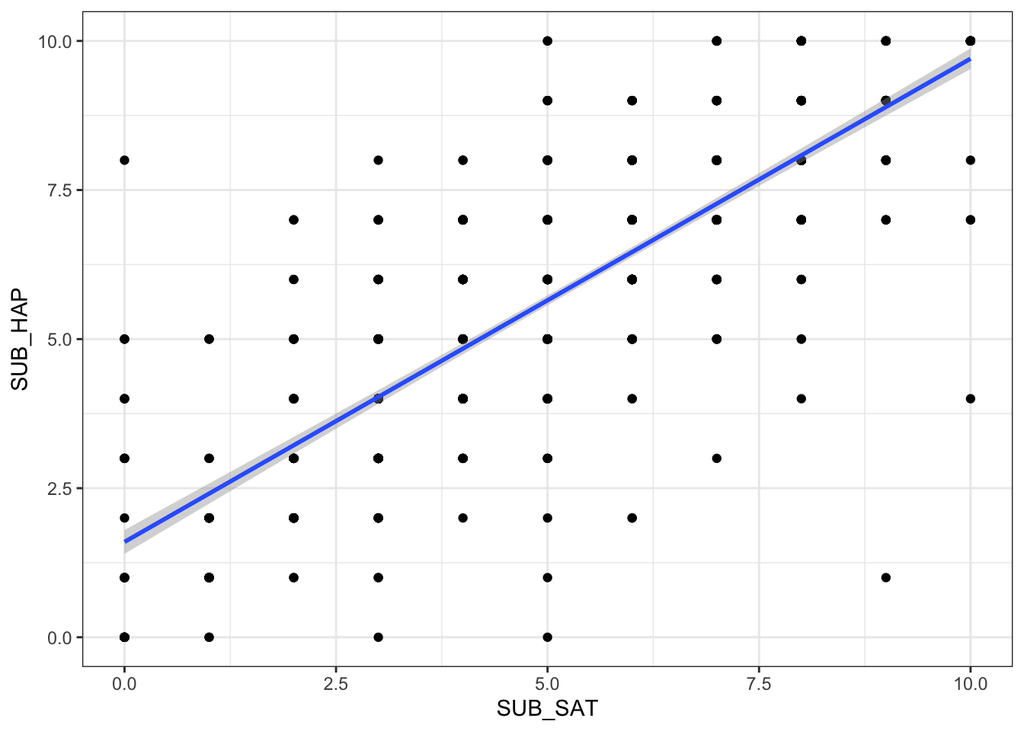

```r
# You need the following package(s):
library("ggplot2")

# The code below will generate the graph:
graph <- ggplot(exdataset, aes(x = SUB_SAT, y = SUB_HAP)) +
  geom_point()+
  geom_smooth(se = TRUE, method = 'lm') +
  theme_bw()
graph
```

## 結果

```r
hapsat_model<-lm(SUB_HAP~SUB_SAT, data = exdataset)
summary(hapsat_model)
```

```
##
## Call:
## lm(formula = SUB_HAP ~ SUB_SAT, data = exdataset)
##
## Residuals:
##     Min      1Q  Median      3Q     Max
## -7.8918 -0.6503 -0.0814  0.7289  6.4015
##
## Coefficients:
##             Estimate Std. Error t value Pr(>|t|)
## (Intercept)  1.59853    0.10176   15.71   <2e-16 ***
## SUB_SAT      0.81036    0.01711   47.37   <2e-16 ***
## ---
## Signif. codes:  0 '***' 0.001 '**' 0.01 '*' 0.05 '.' 0.1 ' ' 1
##
## Residual standard error: 1.285 on 961 degrees of freedom
## Multiple R-squared:  0.7002, Adjusted R-squared:  0.6999
## F-statistic:  2244 on 1 and 961 DF,  p-value: < 2.2e-16
```

## 考察

# 分析4：3群以上の平均値の比較：分散分析

## 仮説

- 対立仮説：主観的幸福度の平均値は地域によって異なる．
- 帰無仮説：主観的幸福度の平均値は地域によって異なるとは言えない．

## グラフ

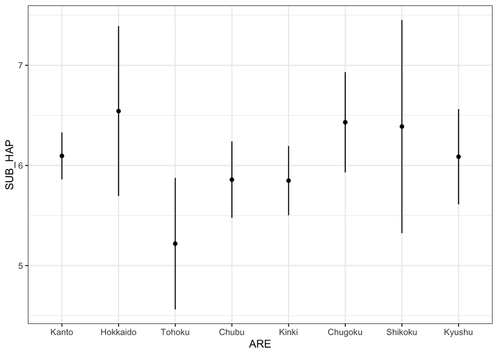

```r
# You need the following package(s):
library("ggplot2")

# The code below will generate the graph:
graph <- ggplot(exdataset, aes(x = ARE, y = SUB_HAP)) +
  geom_point(stat = 'summary', fun.y = 'mean') +
  geom_errorbar(stat = 'summary', fun.data = 'mean_se',
                width=0, fun.args = list(mult = 1.96)) +
  theme_bw()
graph
```

## 結果

```r
arehap_model<-lm(SUB_HAP ~ ARE, data = exdataset)#"hapsat_model"というオブジェクトに，分析モデルを代入する．
anova(arehap_model)#分散分析表
```

```
## Analysis of Variance Table
##
## Response: SUB_HAP
##            Df Sum Sq Mean Sq F value  Pr(>F)
## ARE         7   75.1 10.7238  1.9623 0.05729 .
## Residuals 955 5218.9  5.4648
## ---
## Signif. codes:  0 '***' 0.001 '**' 0.01 '*' 0.05 '.' 0.1 ' ' 1
```

```r
summary(arehap_model)   #分析結果の要約を出力する
```

```
##
## Call:
## lm(formula = SUB_HAP ~ ARE, data = exdataset)
##
## Residuals:
##     Min      1Q  Median      3Q     Max
## -6.5429 -1.4308  0.1515  1.9043  4.7813
##
## Coefficients:
##              Estimate Std. Error t value Pr(>|t|)
## (Intercept)  6.095745   0.120558  50.563  < 2e-16 ***
## AREHokkaido  0.447112   0.413125   1.082  0.27941
## ARETohoku   -0.876995   0.316105  -2.774  0.00564 **
## AREChubu    -0.237637   0.226845  -1.048  0.29510
## AREKinki    -0.247260   0.218299  -1.133  0.25764
## AREChugoku   0.335025   0.314020   1.067  0.28629
## AREShikoku   0.293144   0.564036   0.520  0.60338
## AREKyushu   -0.008788   0.271909  -0.032  0.97422
## ---
## Signif. codes:  0 '***' 0.001 '**' 0.01 '*' 0.05 '.' 0.1 ' ' 1
##
## Residual standard error: 2.338 on 955 degrees of freedom
## Multiple R-squared:  0.01418,    Adjusted R-squared:  0.006954
## F-statistic: 1.962 on 7 and 955 DF,  p-value: 0.05729
```

## 考察

$(主観的幸福度)=0.447112*(北海道ダミー)-0.876995*(東北ダミー)-0.237637*(中部ダミー)-0.247260*(近畿ダミー)$ $+0.335025*(中国ダミー)+0.293144*(四国ダミー)-0.008788*(九州ダミー)+6.095745 + \epsilon_i$